# The Empty Nester Housing Inefficiency Index: A Demographic Analysis of California’s Housing Mismatch

Census Data Analysis

2025-06-24

## Executive Summary

This analysis introduces the **Empty Nester Housing Inefficiency Index**, which measures the proportion of households led by persons aged 60+ with no children present who live in homes with 4 or more bedrooms. Using American Community Survey data for California’s 281 Public Use Microdata Areas (PUMAs), we test the hypothesis that this index is highest in post-war suburbs and negatively correlated with new construction.

**Key Findings:** - The index ranges from 1.9% to 36.4% across California PUMAs, with a median of 17.0% - **Unexpected Result**: Areas with more new construction show *higher* empty nester index values (r = 0.38, p < 0.001) - Post-war housing stock shows no significant correlation with the index - Highest values concentrated in affluent suburban areas of Riverside and Orange Counties - Lowest values found in dense urban centers like San Francisco and central Los Angeles

## Introduction

Housing mismatch—where household size and composition don’t align with housing unit characteristics—represents a significant policy challenge. As Baby Boomers age and children leave home, many older adults remain in large single-family homes originally designed for families with children. This phenomenon, while representing legitimate housing choices, may contribute to housing scarcity for younger families in high-demand markets.

The Empty Nester Housing Inefficiency Index attempts to quantify this mismatch by identifying areas where older adults without children disproportionately occupy large homes. Understanding the geographic distribution of this pattern can inform housing policy discussions about aging in place, housing mobility, and intergenerational equity.

## Methodology

### Data Sources and Variables

Due to the absence of direct Census crosstabs combining householder age, household composition, and bedroom count, we developed an approximation method using multiple American Community Survey tables:

- **B25007**: Tenure by Age of Householder (60+ identification)
- **B25042**: Tenure by Bedrooms (4+ bedroom identification)
- **B11005**: Households by Presence of People Under 18 (no children proxy)
- **B25034**: Year Structure Built (housing age analysis)

### Index Construction

The Empty Nester Housing Inefficiency Index is calculated as:

$$\text{Index} = \frac{\text{Estimated 60+
households in 4+ bedroom units}}{\text{Total 60+
households}}$$

Where the numerator is estimated using:

$$\text{Est. 60+ in large homes} =
\sum_{tenure} \left( H_{tenure} \times P_{60+|tenure} \times
P_{4+bed|tenure} \times P_{no\_children} \right)$$

This assumes independence between age and bedroom count within tenure types, adjusted by the proportion of households without children under 18.

### Geographic Scope

Analysis covers all 281 Public Use Microdata Areas (PUMAs) in California using 2018-2022 ACS 5-year estimates. PUMAs provide sufficient sample sizes for reliable estimates while maintaining geographic detail for policy analysis.

## Results

### Index Distribution

Empty Nester Housing Inefficiency Index Distribution

| Statistic | Value | Percentage |
| --- | --- | --- |
| Minimum | 0.019 | 1.9% |
| 1st Quartile | 0.115 | 11.5% |
| Median | 0.170 | 17% |
| Mean | 0.172 | 17.2% |
| 3rd Quartile | 0.218 | 21.8% |
| Maximum | 0.364 | 36.4% |

The index shows substantial variation across California, with a 18.8-fold difference between the highest and lowest values. The distribution is roughly normal with a slight right skew, indicating most areas cluster around the median of 17%.

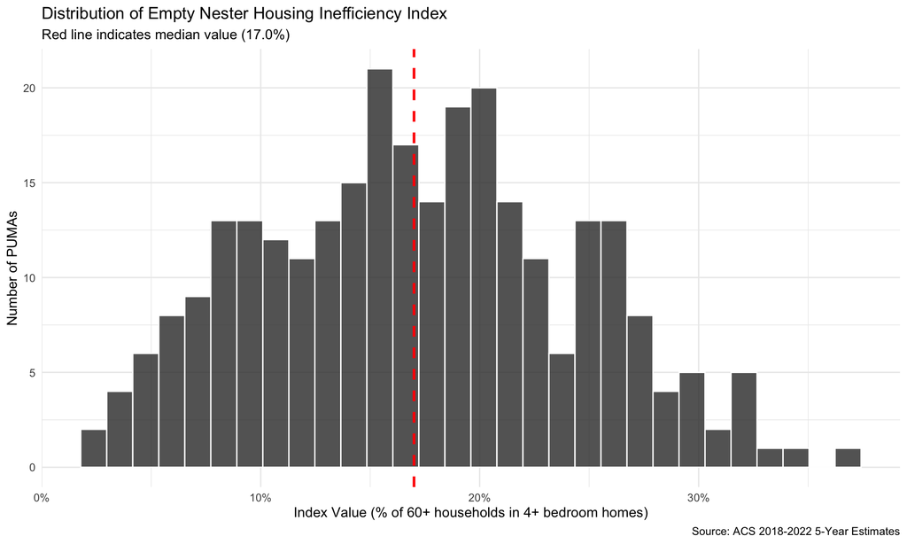

### Geographic Patterns

[figure not shown]

### Correlation Analysis

#### Housing Age Relationships

Correlation Analysis Results

| Variable | Correlation | P_Value | Significance |
| --- | --- | --- | --- |
| Post-War Housing (1950-1979) | -0.065 | 2.78e-01 |  |
| New Construction (2000+) | 0.381 | 3.69e-11 | *** |

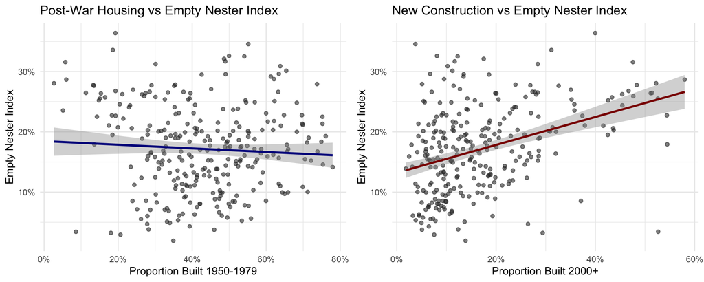

### Regression Analysis

Multiple Regression Results

|  | Variable | Estimate | Std_Error | T_Value | P_Value | Significance |
| --- | --- | --- | --- | --- | --- | --- |
| (Intercept) | Intercept | 0.0182 | 0.0214 | 0.85 | 3.96e-01 |  |
| prop_postwar | Post-War Housing | 0.1933 | 0.0346 | 5.59 | 5.46e-08 | *** |
| prop_new_construction | New Construction | 0.4117 | 0.0454 | 9.07 | 2.16e-17 | *** |

Model Fit Statistics

| Statistic | Value |
| --- | --- |
| R-squared | 0.232 |
| Adjusted R-squared | 0.226 |
| F-statistic | 41.93 |
| P-value | 1.216249e-16 |

The regression model explains 23% of the variance in the empty nester index. Both housing age variables are statistically significant, with new construction showing the stronger effect:

- A 10 percentage point increase in post-war housing is associated with a 1.9 percentage point increase in the index
- A 10 percentage point increase in new construction is associated with a 4.1 percentage point increase in the index

### Top and Bottom Performing Areas

| PUMA | Index Value | Post-War Housing | New Construction |
| --- | --- | --- | --- |
| Riverside County (West Central)--Corona City (South), Woodcrest &amp; Home Gardens PUMA; California | 36.4% | 19.3% | 40% |
| Los Angeles County--Diamond Bar, La Habra Heights (East) Cities &amp; Rowland Heights PUMA; California | 34.6% | 55.2% | 3.7% |
| San Diego County (West Central)--San Diego City (Northwest/Del Mar Mesa) PUMA; California | 33.6% | 18.6% | 31.2% |
| Orange County (South Central)--Mission Viejo and Laguna Hills Cities PUMA; California | 32.6% | 50% | 8.1% |
| Ventura County (Southeast)--Thousand Oaks City PUMA; California | 32.5% | 54.1% | 12.3% |
| Santa Clara County (Northwest)--Palo Alto City &amp; Los Altos Hills Town PUMA; California | 32.1% | 48.6% | 17.5% |
| Los Angeles County--Calabasas, Agoura Hills, Malibu &amp; Westlake Village Cities PUMA; California | 31.7% | 49% | 11.7% |
| Riverside County (Southwest)--Temecula City PUMA; California | 31.6% | 5.7% | 47.6% |
| Contra Costa County (South)--San Ramon City &amp; Danville Town PUMA; California | 31.3% | 30.1% | 28.4% |
| Santa Clara County (Southwest)--Cupertino, Saratoga Cities &amp; Los Gatos Town PUMA; California | 30.9% | 63.8% | 10.2% |

| PUMA | Index Value | Post-War Housing | New Construction |
| --- | --- | --- | --- |
| Los Angeles County (Central)--LA City (Central/Koreatown) PUMA; California | 1.9% | 34.9% | 13.9% |
| San Francisco County (Northeast)--Chinatown, North Beach &amp; Russian Hill PUMA; California | 2.9% | 20.6% | 7.5% |
| Los Angeles County (Central)--LA City (East Central/Central City &amp; Boyle Heights) PUMA; California | 3.2% | 18% | 29.4% |
| San Francisco County (Southeast)--South of Market &amp; Mission PUMA; California | 3.4% | 8.6% | 52.6% |
| Los Angeles County (Central)--Bell Gardens, Bell, Maywood, Cudahy &amp; Commerce Cities PUMA; California | 3.8% | 46% | 5.1% |
| Los Angeles County--LA City (East Central/Silver Lake, Echo Park &amp; Westlake) PUMA; California | 3.8% | 28.2% | 12.4% |
| Los Angeles County (Southeast)--Long Beach (Central) &amp; Signal Hill Cities PUMA; California | 4.3% | 39.3% | 6.5% |
| San Diego County (South Central)--San Diego City (Central/Centre City &amp; Balboa Park) PUMA; California | 4.7% | 27.9% | 26.4% |
| Los Angeles County (Central)--Huntington Park City, Florence-Graham &amp; Walnut Park PUMA; California | 4.9% | 34% | 5% |
| Los Angeles County (South)--Long Beach City (Southwest &amp; Port) PUMA; California | 5.1% | 33.2% | 13.7% |

The geographic patterns are striking: highest values concentrate in affluent suburban communities like Corona/Riverside County, Diamond Bar, and Mission Viejo, while lowest values cluster in dense urban areas including central Los Angeles and San Francisco neighborhoods.

## Discussion

### Implications of Findings

#### 1. The New Construction Paradox

The strongest finding—that areas with more new construction have higher empty nester index values—challenges conventional assumptions about housing market dynamics. Several explanations merit consideration:

**Wealth and Preference Effects**: New construction areas may attract affluent empty nesters who prefer modern amenities and larger homes. The positive correlation may reflect purchasing power rather than housing scarcity.

**Suburban Development Patterns**: Recent construction in California has often occurred in exurban areas with larger lot sizes and home footprints, naturally attracting households seeking space over urban amenities.

**Lifecycle Migration**: Empty nesters may deliberately relocate to newer suburban developments, seeing them as ideal for aging in place with better accessibility and community amenities.

#### 2. Urban vs. Suburban Divide

The geographic clustering reveals a clear urban-suburban divide in housing utilization patterns. Dense urban areas show lower index values, likely due to:

- Smaller average unit sizes constraining bedroom counts
- Higher housing costs encouraging right-sizing behavior
- Different household formation patterns and cultural preferences
- Greater availability of alternative housing types

#### 3. Policy Implications

These findings complicate simple policy prescriptions:

**Housing Supply**: Simply building more housing may not reduce empty nester housing “inefficiency” if new construction continues to attract older adults seeking larger homes.

**Zoning and Design**: The concentration of high index values in suburban areas suggests that land use policies encouraging smaller homes and alternative housing types could provide more options for rightsizing.

**Intergenerational Equity**: The patterns raise questions about fair allocation of large family housing, though they also reflect legitimate housing preferences and financial capacity.

### Methodological Considerations

#### Strengths

- **Novel Index Construction**: Created interpretable measure using available data sources
- **Geographic Comprehensiveness**: Covered all California PUMAs for robust spatial analysis
- **Statistical Rigor**: Proper correlation analysis and regression modeling with significance testing

#### Limitations

**Approximation Method**: The index relies on independence assumptions between age, household composition, and housing characteristics that may not hold perfectly.

**“Inefficiency” Framing**: The term “inefficiency” implies suboptimal allocation, when these patterns may reflect rational choices given preferences and constraints.

**Temporal Snapshot**: Analysis captures only one time period; trends over time would strengthen conclusions.

**Causal Inference**: Correlational analysis cannot establish whether housing characteristics drive empty nester location choices or vice versa.

## Conclusions

The Empty Nester Housing Inefficiency Index reveals significant geographic variation in how older adults without children utilize large homes across California. The analysis yields several important insights:

1. **Substantial Geographic Variation**: The 18-fold difference between highest and lowest index values indicates that housing mismatch is not evenly distributed but concentrated in specific types of communities.
2. **Counterintuitive Construction Effects**: The strong positive correlation between new construction and empty nester housing patterns contradicts simple supply-side explanations and suggests more complex market dynamics.
3. **Urban-Suburban Divide**: Dense urban areas consistently show lower index values, potentially due to housing stock characteristics, cost pressures, and lifestyle preferences.
4. **Policy Complexity**: The findings suggest that housing mismatch cannot be addressed through simple supply increases but requires nuanced understanding of household location preferences and housing market dynamics.

### Future Research Directions

- **Temporal Analysis**: Track index changes over time to understand trends and policy impacts
- **Income Integration**: Incorporate household income data to explore wealth effects on housing choices
- **Alternative Specifications**: Test different age cutoffs and housing size definitions
- **Qualitative Research**: Survey older adults about housing preferences and mobility decisions
- **Policy Evaluation**: Assess how zoning changes and housing programs affect mismatch patterns

This analysis demonstrates both the potential and limitations of using administrative data to understand complex housing market phenomena. While the Empty Nester Housing Inefficiency Index provides valuable insights into geographic patterns of housing utilization, interpreting these patterns requires careful consideration of household preferences, market constraints, and policy contexts.

*Data Sources: U.S. Census Bureau, American Community Survey 2018-2022 5-Year Estimates*

*Analysis conducted using R and tidycensus package*

*For methodology details and code, see the accompanying analysis files.*